# Lab05

Chi Sun

2023-11-27

```r
# Loading the terra library for spatial data manipulation
library(terra)

# Importing land cover/use data and other spatial layers
NLCD_2001 <- rast("NLCD_2001_SL.tif")
NLCD_2016 <- rast("NLCD_2016_SL.tif")
Park_dist <- rast("Parks_dist_SL.tif")  # Distance to parks (Euclidean)
Rd_dns1km <- rast("Rd_dns1km_SL.tif")  # Road density
WaterDist <- rast("WaterDist_SL.tif")  # Distance to water bodies (Euclidean)
DEM <- rast("DEM_SL.tif")  # Elevation data
allrasters <- c(NLCD_2001, NLCD_2016, Park_dist, Rd_dns1km, WaterDist, DEM)
```

```r
# Loading required libraries for spatial sampling and analysis
library(leaflet)
library(ape)
set.seed(10086)  # Setting seed for reproducibility

# Generating random and regular spatial samples from the raster data
sampleSLrnd <- spatSample(allrasters, size=100, "random", cells=TRUE, xy=TRUE)
sampleSLreg <- spatSample(allrasters, size=100, "regular", cells=TRUE, xy=TRUE)

# Flattening the spatial data to a dataframe with latitude and longitude
flat_data <- as.data.frame(sampleSLrnd)
flat_data = na.omit(flat_data)

# Calculating distances between points and creating an inverse distance matrix
dist_matrix <- as.matrix(dist(cbind(flat_data$x, flat_data$y)))
dist_matix.inv <- 1/dist_matrix
diag(dist_matix.inv) <- 0

# Calculating Moran's I for road density
Moran.I(flat_data$Rd_dns1km_SL, dist_matix.inv)
```

```
## $observed
## [1] 0.2076436
##
## $expected
## [1] -0.01587302
##
## $sd
## [1] 0.02761467
##
## $p.value
## [1] 6.661338e-16
```

```r
# Loading tidyverse for data manipulation
library(tidyverse)

# Converting all raster layers to a dataframe and filtering out no data values
allrastersSL <- as.data.frame(allrasters, xy=TRUE)
allrastersSL <- allrastersSL %>%
  filter (NLCD_2001_SL != 128)  # Removing no data values

allrastersSL <- allrastersSL %>%
    mutate(urbanChg =
             # Places that are not urban in 2001
             (NLCD_2001_SL != 21 & NLCD_2001_SL != 22 & NLCD_2001_SL != 23 & NLCD_2001_SL != 24)
           &  # and
             # is now urban in 2016
             (NLCD_2016_SL == 21 | NLCD_2016_SL == 22  | NLCD_2016_SL == 23 | NLCD_2016_SL == 24)
           )

# Loading additional libraries for data manipulation
library(dplyr)
library(plyr)
library(reshape2)
library(plotly)

# Filtering and categorizing urban and non-urban areas from the data
SL <- allrastersSL %>%
  filter(NLCD_2001_SL != 21 & NLCD_2001_SL != 22 & NLCD_2001_SL != 23 & NLCD_2001_SL != 24)

# Extracting developed (urban) and undeveloped (non-urban) cells
newUrban <- SL %>% filter(urbanChg == TRUE)
nonUrban <- SL %>% filter(urbanChg == FALSE)

# Sampling undeveloped data to be twice as large as developed data
index <- sample(1:nrow(nonUrban), (round(nrow(newUrban) * 2)))
SLsampleUrban <- nonUrban[index, ]

# Combining original developed and sampled undeveloped data
SLsample <- rbind(SLsampleUrban, newUrban)

# Subsampling data for training and testing datasets
index <- sample(1:nrow(SLsample), (round(nrow(SLsample) * 0.01)))
SLsample <- SLsample[index, ]

# Adding an ID column for splitting data into training and test sets
SLsample <- SLsample %>% dplyr::mutate(id = row_number())
```

```r
# Creating training set (70% of data)
train <- SLsample %>% sample_frac(.70)

# Creating test set (remaining 30% of data)
test <- anti_join(SLsample, train, by = 'id')

# Fitting a logistic regression model with binomial family
fit <- glm(urbanChg ~ Parks_dist_SL + Rd_dns1km_SL + WaterDist_SL + DEM_SL, data=train, family=binomial())
# Displaying model summary
summary(fit)
```

```
##
## Call:
## glm(formula = urbanChg ~ Parks_dist_SL + Rd_dns1km_SL + WaterDist_SL +
##     DEM_SL, family = binomial(), data = train)
##
## Coefficients:
##                 Estimate Std. Error z value Pr(>|z|)
## (Intercept)    5.235e+00  7.332e-01   7.140 9.34e-13 ***
## Parks_dist_SL  8.843e-05  1.617e-05   5.470 4.50e-08 ***
## Rd_dns1km_SL   2.085e+01  1.168e+00  17.843  < 2e-16 ***
## WaterDist_SL   2.731e-04  8.304e-05   3.289  0.00101 **
## DEM_SL        -5.839e-03  5.591e-04 -10.444  < 2e-16 ***
## ---
## Signif. codes:  0 '***' 0.001 '**' 0.01 '*' 0.05 '.' 0.1 ' ' 1
##
## (Dispersion parameter for binomial family taken to be 1)
##
##     Null deviance: 2775.6  on 2206  degrees of freedom
## Residual deviance: 1146.7  on 2202  degrees of freedom
## AIC: 1156.7
##
## Number of Fisher Scoring iterations: 7
```

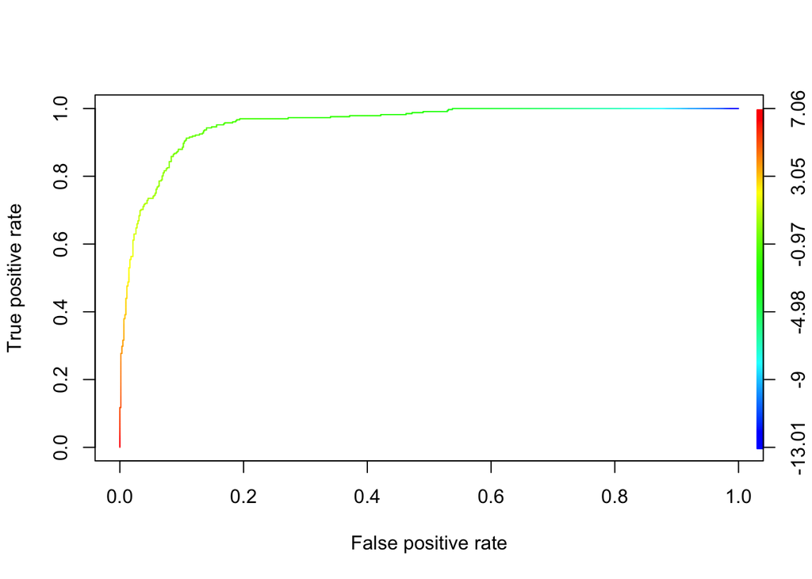

```r
# Loading required package for ROC analysis
library(ROCR)

# Generating ROC curve for model prediction and coloring it by cutoff
pred_label <- predict(fit, newdata = test)
pred <- prediction(pred_label, test$urbanChg)
perf <- performance(pred, "tpr", "fpr")
plot(perf, colorize = TRUE)
```

```r
# Calculating and displaying AUC for model evaluation
auc_ROCR <- performance(pred, measure = "auc")
auc_ROCR <- auc_ROCR@y.values[[1]]
auc_ROCR
```

```
## [1] 0.9561438
```

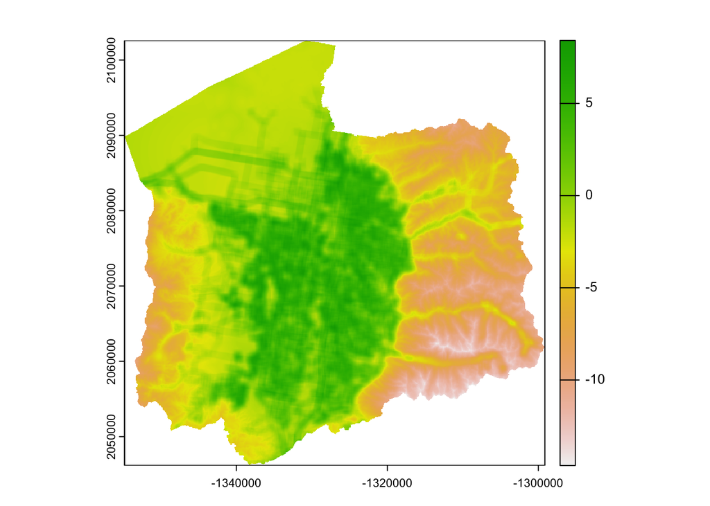

```r
# Generating predictions using the fitted model on all raster data
predicted <- predict(allrasters, fit)
# Plotting the predicted values
plot(predicted)
```

Analyze the Salt Lake City dataset. Fit a model that explains suitability for urban development (provide evidence of goodness of model fit). What characteristics contribute to urban development in Salt Lake? What variable might you add to better explain urban development. (1-2 paragraphs)

As the model shows above, I use the NLCD 2001, NLCD 2016 as data source. Road density, distance to water body, distance to park and elevation of Saltlake city as independent variables. To fit the model, we use GLM model and binomial family. From the fit summary of the model, we can tell that all the factors we put into consideration have significant influence on saltlake city urbanization.

I will add demographic data like population density, age distribution, and household composition as factors to describe the urbanization. High population density often signifies urban areas with developed infrastructure and amenities, while lower densities are typical of rural or suburban regions. This density influences various aspects of urban planning, including the need for housing, transportation, and public services.This distribution impacts the demand for different types of services and infrastructure. For example, a youthful population may increase the need for schools and recreational facilities Age distribution entails the proportions of various age groups within a population, such as children, working-age adults, and the elderly.

```r
library(fastcluster)
library(graphics)
library(ggplot2)
library(ggdendro)
library(sf)
amenData<- st_read("AmenDataAll.shp")
st_geometry(amenData)
```

[output not shown]

```r
geomData = st_sfc(amenData$geometry)
```

```r
amenData$ZooEmpDist_log <- log(amenData$ZooDistEmp + 0.00000001)
amenData$HotelEmpDist_log <- log(amenData$HotelDistE + 0.00000001)
amenData$HistMonDist_log <- log(amenData$HistMon_Di + 0.00000001)
amenData$HighEdEmpDist_log <- log(amenData$HigherEdDi + 0.00000001)
amenData$GolfEmpDist_log <- log(amenData$GolfDistEm + 0.00000001)
amenData$SocialNorm <- amenData$Nat_Flickr/(amenData$serPop10 + 1)
amenData$HousingChg <- amenData$Urb2011 - amenData$Urb2001

amenDataDF<-amenData[,c("SocialNorm", "HousingChg", "Frst2011", "WaterPct", "distcoast", "DEM_max","DEM_range", "HikeLength","ZooEmpDist_log", "HotelEmpDist_log","HistMonDist_log", "HighEdEmpDist_log", "GolfEmpDist_log")]

amenDataDF <- na.omit(amenDataDF)
amenDataDF <- as.data.frame(amenDataDF)[1:12]
db_scaled <- scale(amenDataDF)
```

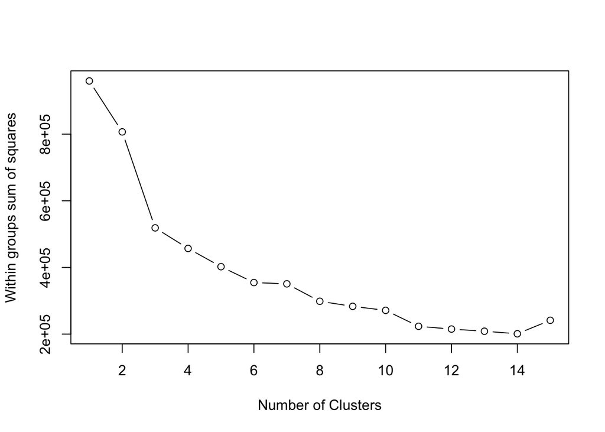

```r
# Determine number of clusters
wss <- (nrow(db_scaled)-1)*sum(apply(db_scaled,2,var))
for (i in 2:15) wss[i] <- sum(kmeans(db_scaled,
   centers=i)$withinss)
plot(1:15, wss, type="b", xlab="Number of Clusters",
  ylab="Within groups sum of squares")
```

```r
# K-Means Cluster Analysis
fit <- kmeans(db_scaled, 5) # 5 cluster solution
aggregate(db_scaled,by=list(fit$cluster),FUN=mean)
```

```
##   Group.1  SocialNorm HousingChg   Frst2011   WaterPct  distcoast    DEM_max
## 1       1 -0.04824981 -0.6446778 -0.6434355  0.2356249 -0.4463548 -0.6864157
## 2       2 -0.06944437  0.8916338 -0.6434355 -0.3234747 -1.2459424 -1.0590124
## 3       3 -0.06201327 -0.3360159  1.5541379  0.1819493 -0.7200205 -0.6253272
## 4       4 -0.04146677  0.4874485 -0.6381711 -0.2280389  1.0317800  0.4896887
## 5       5  0.28194618  0.6776289  0.5781049 -0.2349091  0.2665703  1.6249080
##    DEM_range HikeLength ZooEmpDist_log HotelEmpDist_log HistMonDist_log
## 1 -0.5276412 -0.3801543      0.1968055        0.1859794       0.1388890
## 2 -0.7926785 -0.6059234     -4.8483172       -4.9382400      -4.9810208
## 3 -0.2512438 -0.1488626      0.1855832        0.1619043       0.1648106
## 4 -0.1598597  0.3181011      0.1941374        0.1796083       0.2395450
## 5  1.9464204  0.5438402      0.1206917        0.2250616       0.2163688
##   HighEdEmpDist_log
## 1         0.2083110
## 2        -4.7375877
## 3         0.2115052
## 4         0.1487403
## 5         0.1206119
```

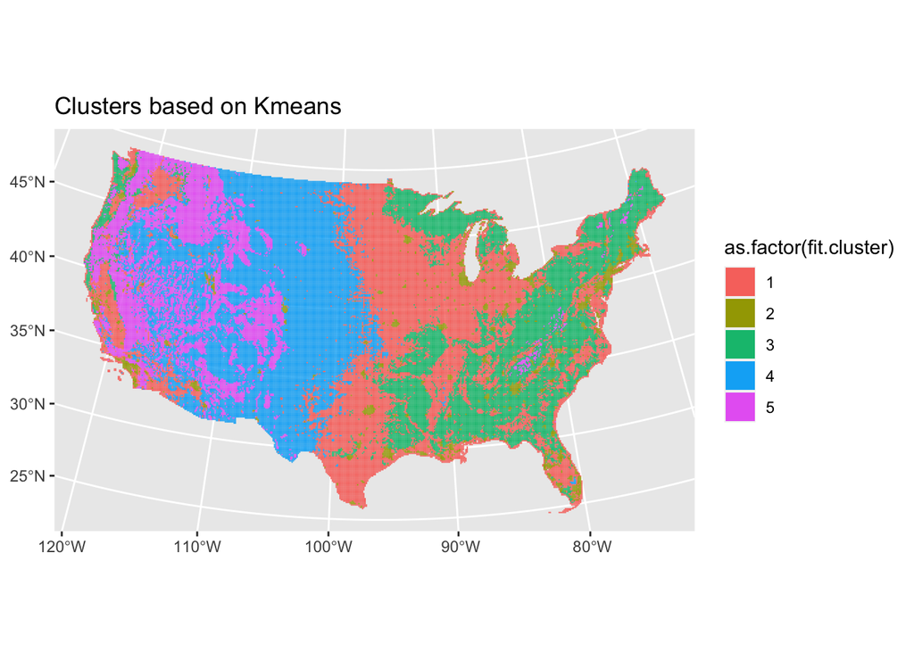

```r
amenData <- data.frame(amenData, fit$cluster)
st_geometry(amenData) <- geomData
ggplot() +
  geom_sf(data = amenData, mapping = aes(fill = as.factor(fit.cluster)), color = NA) +
  theme(legend.position = "right") +
  ggtitle("Clusters based on Kmeans")
```

Analyze the database of amenity landscape characteristics using a clustering technique. Choose variables based on a thematic inquiry of your choice. Visualize ad provide qualitative descriptions of the groups that you derive from the clustering techniques. Provide evidence of you characterizations. Provide a map of your cluster analysis. Give an explanation of the spatial distribution of these groups. (1-2 paragraphs)